# Week 12

## Introduction to Regressions

- binary means (close vs far)
- pre-specified categories with means
- simple linear regression (OLS)
- analysis of the results
- Log models
- Non-linear models

#### Dataset:

- hotels-vienna

## Introduction to Regression

Import packages

```python
import numpy as np
import pandas as pd

import matplotlib.pyplot as plt
import seaborn as sns


%matplotlib inline
plt.style.use('fivethirtyeight')
#sns.set_style("dark")


pd.set_option('display.max_columns',50)
```

From OSF import hotel-vienna data

```python
hotels = pd.read_csv("https://osf.io/y6jvb/download")
```

```python
hotels
```

|  | country | city_actual | rating_count | center1label | center2label | neighbourhood | price | city | stars | ratingta | ratingta_count | scarce_room | hotel_id | offer | offer_cat | year | month | weekend | holiday | distance | distance_alter | accommodation_type | nnights | rating |
| --- | --- | --- | --- | --- | --- | --- | --- | --- | --- | --- | --- | --- | --- | --- | --- | --- | --- | --- | --- | --- | --- | --- | --- | --- |
| 0 | Austria | Vienna | 36.0 | City centre | Donauturm | 17. Hernals | 81 | Vienna | 4.0 | 4.5 | 216.0 | 1 | 21894 | 1 | 15-50% offer | 2017 | 11 | 0 | 0 | 2.7 | 4.4 | Apartment | 1 | 4.4 |
| 1 | Austria | Vienna | 189.0 | City centre | Donauturm | 17. Hernals | 81 | Vienna | 4.0 | 3.5 | 708.0 | 0 | 21897 | 1 | 1-15% offer | 2017 | 11 | 0 | 0 | 1.7 | 3.8 | Hotel | 1 | 3.9 |
| 2 | Austria | Vienna | 53.0 | City centre | Donauturm | Alsergrund | 85 | Vienna | 4.0 | 3.5 | 629.0 | 0 | 21901 | 1 | 15-50% offer | 2017 | 11 | 0 | 0 | 1.4 | 2.5 | Hotel | 1 | 3.7 |
| 3 | Austria | Vienna | 55.0 | City centre | Donauturm | Alsergrund | 83 | Vienna | 3.0 | 4.0 | 52.0 | 0 | 21902 | 1 | 15-50% offer | 2017 | 11 | 0 | 0 | 1.7 | 2.5 | Hotel | 1 | 4.0 |
| 4 | Austria | Vienna | 33.0 | City centre | Donauturm | Alsergrund | 82 | Vienna | 4.0 | 3.5 | 219.0 | 1 | 21903 | 1 | 15-50% offer | 2017 | 11 | 0 | 0 | 1.2 | 2.8 | Hotel | 1 | 3.9 |
| ... | ... | ... | ... | ... | ... | ... | ... | ... | ... | ... | ... | ... | ... | ... | ... | ... | ... | ... | ... | ... | ... | ... | ... | ... |
| 423 | Austria | Vienna | 2.0 | City centre | Donauturm | Wieden | 109 | Vienna | 3.0 | 3.0 | 14.0 | 1 | 22404 | 1 | 50%-75% offer | 2017 | 11 | 0 | 0 | 1.5 | 3.8 | Apartment | 1 | 5.0 |
| 424 | Austria | Vienna | 145.0 | City centre | Donauturm | Wieden | 185 | Vienna | 5.0 | 4.0 | 740.0 | 0 | 22406 | 1 | 15-50% offer | 2017 | 11 | 0 | 0 | 0.8 | 3.6 | Hotel | 1 | 4.3 |
| 425 | Austria | Vienna | 112.0 | City centre | Donauturm | Wieden | 100 | Vienna | 4.0 | 4.5 | 1006.0 | 1 | 22407 | 0 | 0% no offer | 2017 | 11 | 0 | 0 | 1.0 | 3.7 | Hotel | 1 | 4.4 |
| 426 | Austria | Vienna | 169.0 | City centre | Donauturm | Wieden | 58 | Vienna | 3.0 | 3.0 | 135.0 | 0 | 22408 | 1 | 15-50% offer | 2017 | 11 | 0 | 0 | 1.4 | 4.1 | Hotel | 1 | 3.2 |
| 427 | Austria | Vienna | 80.0 | City centre | Donauturm | Wieden | 110 | Vienna | 3.5 | NaN | NaN | 1 | 22409 | 1 | 1-15% offer | 2017 | 11 | 0 | 0 | 0.7 | 3.5 | Apartment | 1 | 4.0 |

428 rows × 24 columns

```python
hotels.shape
```

```
(428, 24)
```

Apply filters: 3-4 stars, Vienna actual, without extreme prices

```python
hotels = (
    hotels.loc[lambda x: x["accommodation_type"] == "Hotel"]
    .loc[lambda x: x["city_actual"] == "Vienna"]
    .loc[lambda x: x["stars"] >= 3]
    .loc[lambda x: x["stars"] <= 4]
    .loc[lambda x: x["stars"].notnull()]
    .loc[lambda x: x["price"] <= 600]
)
#hotels = hotels[(hotels["accommodation_type"] == "Hotel")
#                & (hotels["city_actual"] == "Vienna")
#                & (hotels["stars"] >= 3)
#                & (hotels["stars"] <= 4)
#                & (hotels["stars"].notnull())
#                & (hotels["price"] <= 600)]
```

This code filters a pandas DataFrame named `hotels` to only include rows where the value in the "accommodation_type" column is "Hotel", the value in the "city_actual" column is "Vienna", the value in the "stars" column is greater than or equal to 3 and less than or equal to 4, the value in the "stars" column is not null, and the value in the "price" column is less than or equal to 600.

Here's a step-by-step breakdown of what each line is doing:

1. `hotels.loc[lambda x: x["accommodation_type"] == "Hotel"]`: Select only rows where the value in the "accommodation_type" column is "Hotel".
2. `.loc[lambda x: x["city_actual"] == "Vienna"]`: Further filter the result from step 1 to only include rows where the value in the "city_actual" column is "Vienna".
3. `.loc[lambda x: x["stars"] >= 3]`: Further filter the result from step 2 to only include rows where the value in the "stars" column is greater than or equal to 3.
4. `.loc[lambda x: x["stars"] <= 4]`: Further filter the result from step 3 to only include rows where the value in the "stars" column is less than or equal to 4.
5. `.loc[lambda x: x["stars"].notnull()]`: Further filter the result from step 4 to only include rows where the value in the "stars" column is not null.
6. `.loc[lambda x: x["price"] <= 600]`: Finally, further filter the result from step 5 to only include rows where the value in the "price" column is less than or equal to 600.

So, the resulting DataFrame will only include rows where all of these conditions are met.

You can also use the commented out code in the previous to get the same result!

Summary statistics on price and distance

```python
hotels.filter(["price", "distance"]).describe(percentiles=[0.25, 0.5, 0.75, 0.95]).T
```

|  | count | mean | std | min | 25% | 50% | 75% | 95% | max |
| --- | --- | --- | --- | --- | --- | --- | --- | --- | --- |
| price | 207.0 | 109.975845 | 42.221381 | 50.0 | 82.0 | 100.0 | 129.5 | 183.4 | 383.0 |
| distance | 207.0 | 1.529952 | 1.161507 | 0.0 | 0.8 | 1.3 | 1.9 | 3.9 | 6.6 |

Graphical investigation:  
create a base scatter-plot between price and distance

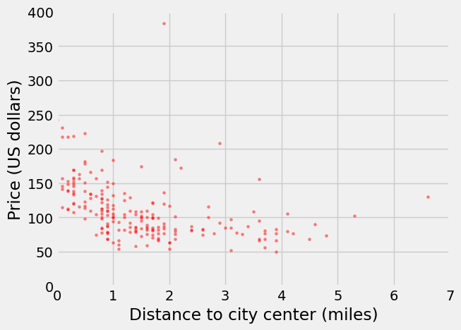

```python
# Create scatterplot with seaborn
sns.scatterplot(data=hotels, x="distance", y="price", color="red", alpha=0.5, s=12)

# Set x and y limits
plt.xlim(0, 7)
plt.ylim(0, 400)

# Set x and y ticks
plt.xticks(range(0, 8))
plt.yticks(np.arange(0, 401, 50))

# Set axis labels
plt.xlabel("Distance to city center (miles)")
plt.ylabel("Price (US dollars)")

# Show the plot
plt.show()
```

### Binary Variable

Close vs Far away hotels with a binary variable:

- if further away from 2 miles, consider as 'far', otherwise 'close'

```python
hotels["dist2"] = np.where(hotels["distance"] >= 2, "Far", "Close")
hotels["Eprice_cat2"] = hotels.groupby("dist2")["price"].transform("mean")
```

The first line of code is creating a new column named dist2, which is calculated using the `NumPy` `where()` function. The `where()` function takes three arguments: a *boolean* condition, a value to use if the condition is *true*, and a value to use if the condition is *false*. In this case, the boolean condition is whether the distance column is greater than or equal to 2. If the condition is true, the value in the new `dist2` column will be "Far". If the condition is false (i.e., the distance is less than 2), the value in the new `dist2` column will be "Close".

The second line of code is creating a new column named `Eprice_cat2`, which is the mean price value grouped by the `dist2` column. The `groupby()` function is used to group the DataFrame by the values in the `dist2` column, and the `transform()` method is used to apply the `mean()` function to the price column within each group. The result is a new column with the mean price value for each group (i.e., "Close" and "Far").

Overall, this code is creating two new columns in the DataFrame that categorize the distance between each hotel and the city center as "Close" or "Far", and then calculates the mean price value for each category.

Check the descriptives for the two categories:

```python
(
    hotels.melt(id_vars="dist2", value_vars=["distance", "price"], value_name="price_value")
    .groupby(["dist2", "variable"])
    .agg(["mean", "std", "min", "max", "count"])
    .round(2)
)
```

| dist2 | variable | price_value mean | price_value std | price_value min | price_value max | price_value count |
| --- | --- | --- | --- | --- | --- | --- |
| Close | distance | 0.99 | 0.54 | 0.0 | 1.9 | 157 |
|  | price | 116.43 | 43.10 | 54.0 | 383.0 | 157 |
| Far | distance | 3.21 | 0.97 | 2.0 | 6.6 | 50 |
|  | price | 89.72 | 32.09 | 50.0 | 208.0 | 50 |

The result of these operations is a new DataFrame that shows the mean, standard deviation, minimum, maximum, and count of the `distance` and `price` variables for each `dist2` category. By grouping the data this way and calculating summary statistics, this code provides a way to compare the two categories based on these variables.

Plot the two categories

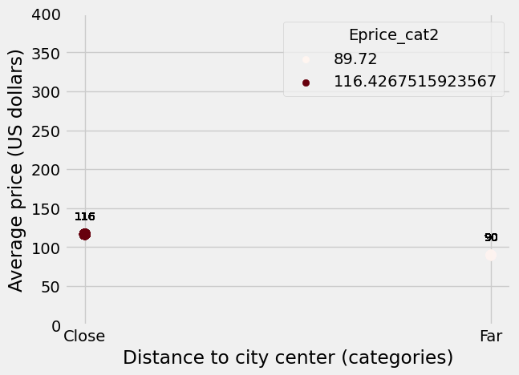

```python
# Create scatterplot with colored markers
sns.scatterplot(
    data=hotels,
    x="dist2",
    y="Eprice_cat2",
    hue="Eprice_cat2",
    palette="Reds",
    alpha=0.4,
    edgecolor="none",
    s=100,
)

# Add labels to markers
for x, y, val in zip(hotels["dist2"], hotels["Eprice_cat2"], hotels["Eprice_cat2"].round()):
    plt.text(x, y+16, int(val), ha="center", va="bottom", fontsize=10)

# Set axis limits and labels
plt.ylim(0, 400)
plt.yticks(np.arange(0, 401, 50))
plt.xlabel("Distance to city center (categories)")
plt.ylabel("Average price (US dollars)")

# Show plot
plt.show()
```

#### Task:

Instead of a simple dot, use a box-plot, which shows the underlying (conditional) distribution better!

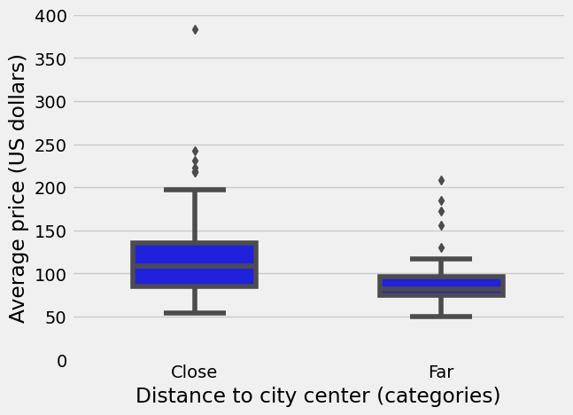

```python
sns.boxplot(data=hotels, x="dist2", y="price", color="blue", width=0.5)
#sns.errorbar(data=hotels, x="dist2", y="price", color="blue", fmt='none', capsize=0.5)
sns.despine()
#sns.set_style("white")
sns.set_palette("pastel")
sns.set_context("talk")
plt.ylim(0, 400)
plt.yticks(np.arange(0, 401, 50))
plt.xlabel("Distance to city center (categories)")
plt.ylabel("Average price (US dollars)")
plt.show()
```

### Pre-specified Categories With Means (4 Distance Categories)

Below 1, between 1 and 2, between 2 and 3 and above 3 -> x value will be the midpoint

```python
hotels["dist4"] = (
    0.5
    + np.where(hotels["distance"] >= 1, 1, 0)
    + np.where(hotels["distance"] >= 2, 1, 0)
    + np.where(hotels["distance"] >= 3, 2.5, 0)
)
```

Add mean values for price given each group

```python
hotels["Eprice_cat4"] = hotels.groupby("dist4")["price"].transform("mean")
```

```python
(
    hotels.melt(id_vars="dist4", value_vars=["distance", "price"], value_name = "price_value")
    .groupby(["dist4", "variable"])
    .agg(["mean", "std", "min", "max", "count"])
    .round(2)
)
```

| dist4 | variable | price_value mean | price_value std | price_value min | price_value max | price_value count |
| --- | --- | --- | --- | --- | --- | --- |
| 0.5 | distance | 0.55 | 0.28 | 0.0 | 0.9 | 81 |
|  | price | 132.91 | 38.54 | 68.0 | 242.0 | 81 |
| 1.5 | distance | 1.46 | 0.29 | 1.0 | 1.9 | 76 |
|  | price | 98.86 | 40.89 | 54.0 | 383.0 | 76 |
| 2.5 | distance | 2.35 | 0.32 | 2.0 | 2.9 | 22 |
|  | price | 97.55 | 40.39 | 54.0 | 208.0 | 22 |
| 5.0 | distance | 3.88 | 0.76 | 3.0 | 6.6 | 28 |
|  | price | 83.57 | 22.60 | 50.0 | 156.0 | 28 |

### Simple Linear Regression

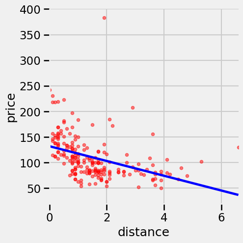

```python
sns.lmplot(x="distance", y="price", data=hotels, scatter_kws={"color": "red", "alpha": 0.5, "s": 20}, line_kws={"color": "blue"}, ci=None)
plt.show()
```

How to quantify linear regression:  
Remember: $y = \alpha + \beta * x + \epsilon$

In Python, the [statsmodels](https://www.statsmodels.org/stable/index.html) package is usually used to estimate regressions

```python
import statsmodels.formula.api as smf
from mizani.formatters import percent_format
```

We use the statsmodels formula api, where you can give the equations as a string

Simple model, with homoskedastic SE

```python
simple_reg = smf.ols("price ~ distance", data=hotels).fit()
print(simple_reg.summary())
```

```
                            OLS Regression Results
==============================================================================
Dep. Variable:                  price   R-squared:                       0.157
Model:                            OLS   Adj. R-squared:                  0.153
Method:                 Least Squares   F-statistic:                     38.20
Date:                Fri, 12 May 2023   Prob (F-statistic):           3.39e-09
Time:                        14:59:32   Log-Likelihood:                -1050.3
No. Observations:                 207   AIC:                             2105.
Df Residuals:                     205   BIC:                             2111.
Df Model:                           1
Covariance Type:            nonrobust
==============================================================================
                 coef    std err          t      P>|t|      [0.025      0.975]
------------------------------------------------------------------------------
Intercept    132.0170      4.474     29.511      0.000     123.197     140.837
distance     -14.4064      2.331     -6.181      0.000     -19.002      -9.811
==============================================================================
Omnibus:                      141.994   Durbin-Watson:                   1.479
Prob(Omnibus):                  0.000   Jarque-Bera (JB):             1560.025
Skew:                           2.497   Prob(JB):                         0.00
Kurtosis:                      15.488   Cond. No.                         3.78
==============================================================================

Notes:
[1] Standard Errors assume that the covariance matrix of the errors is correctly specified.
```

The code performs simple linear regression between the variables `price` and `distance` using the `ols()` function from the `statsmodels.formula.api` module, which provides a formula-based interface to linear regression.

Specifically, it specifies a linear model with `price` as the dependent variable and `distance` as the independent variable. The `.fit()` method is then called on the model to fit it to the data contained in the `hotels` dataframe.

Finally, the `.summary()` method is used to print a summary of the regression results, which includes important information such as the R-squared value, the coefficients and their standard errors, and p-values for hypothesis testing.

Simple model, with heteroskedastic robust SE

```python
hetero_rob_reg = smf.ols("price ~ distance", data=hotels).fit(cov_type ="HC3")
print(hetero_rob_reg.summary())
```

```
                            OLS Regression Results
==============================================================================
Dep. Variable:                  price   R-squared:                       0.157
Model:                            OLS   Adj. R-squared:                  0.153
Method:                 Least Squares   F-statistic:                     28.10
Date:                Fri, 12 May 2023   Prob (F-statistic):           2.97e-07
Time:                        14:59:32   Log-Likelihood:                -1050.3
No. Observations:                 207   AIC:                             2105.
Df Residuals:                     205   BIC:                             2111.
Df Model:                           1
Covariance Type:                  HC3
==============================================================================
                 coef    std err          z      P>|z|      [0.025      0.975]
------------------------------------------------------------------------------
Intercept    132.0170      4.876     27.072      0.000     122.459     141.575
distance     -14.4064      2.718     -5.301      0.000     -19.733      -9.080
==============================================================================
Omnibus:                      141.994   Durbin-Watson:                   1.479
Prob(Omnibus):                  0.000   Jarque-Bera (JB):             1560.025
Skew:                           2.497   Prob(JB):                         0.00
Kurtosis:                      15.488   Cond. No.                         3.78
==============================================================================

Notes:
[1] Standard Errors are heteroscedasticity robust (HC3)
```

The `cov_type` parameter is set to `"HC3"`, which indicates that we want to estimate the covariance matrix using the Huber-White estimator with small sample correction.

Its wasy to compare two regression output tables using the stargazer package

```python
from stargazer.stargazer import Stargazer
```

If you do not have the stargazer package. You have to go to your terminal or command prompt and type. `pip install stargazer`. This should definitely work for macbooks!

```python
table = Stargazer([simple_reg, hetero_rob_reg])
table.rename_covariates({"Intercept": "Constant"})
table.custom_columns(["Homoskedastic SE", "Heteroskedastic robust SE"], [1, 1])
table
```

|  | *Dependent variable:price* |  |
| --- | --- | --- |
|  | Homoskedastic SE | Heteroskedastic robust SE |
|  | (1) | (2) |
| Constant | 132.017*** | 132.017*** |
|  | (4.474) | (4.876) |
| distance | -14.406*** | -14.406*** |
|  | (2.331) | (2.718) |
| Observations | 207 | 207 |
| R<sup>2</sup> | 0.157 | 0.157 |
| Adjusted R<sup>2</sup> | 0.153 | 0.153 |
| Residual Std. Error | 38.858 (df=205) | 38.858 (df=205) |
| F Statistic | 38.199*** (df=1; 205) | 28.102*** (df=1; 205) |
| Note: | *p<0.1; **p<0.05; ***p<0.01 |  |

```python
html = table.render_html()

with open("my_regression_table.html", "w") as f:
    f.write(html)

#open('lin_reg.html','w').write(table.render_html())
```

You can use either the one I implement here or the one commented out. If you want to now use this table in MS word or docx files. You just have to open the `my_regression_table.html` file an copy paste it! You will see it should be formated like a table in word.

### Analysis of the Results

- price prediction of a model
- errors of predictions

It is easy to save the predicted values and residuals

```python
hotels["predprice"] = simple_reg.fittedvalues
hotels["e"] = simple_reg.resid
```

Get the hotel, which is the most underpriced

```python
hotels.sort_values(by="e").head(1)
```

|  | country | city_actual | rating_count | center1label | center2label | neighbourhood | price | city | stars | ratingta | ratingta_count | scarce_room | hotel_id | offer | offer_cat | year | month | weekend | holiday | distance | distance_alter | accommodation_type | nnights | rating | dist2 | Eprice_cat2 | dist4 | Eprice_cat4 | predprice | … |
| --- | --- | --- | --- | --- | --- | --- | --- | --- | --- | --- | --- | --- | --- | --- | --- | --- | --- | --- | --- | --- | --- | --- | --- | --- | --- | --- | --- | --- | --- | --- |
| 153 | Austria | Vienna | 63.0 | City centre | Donauturm | Josefstadt | 54 | Vienna | 3.0 | 3.0 | 85.0 | 1 | 22080 | 1 | 15-50% offer | 2017 | 11 | 0 | 0 | 1.1 | 3.4 | Hotel | 1 | 3.2 | Close | 116.426752 | 1.5 | 98.855263 | 116.16991 | … |

probably we are only interested in hotel_id, distance, price, prediction and error values:

```python
hotels.sort_values(by="e").head(1).filter(["hotel_id","distance","price","predprice","e"])
```

|  | hotel_id | distance | price | predprice | e |
| --- | --- | --- | --- | --- | --- |
| 153 | 22080 | 1.1 | 54 | 116.16991 | -62.16991 |

Interpret the result!

We can get the 5 most overpriced five hotels

```python
hotels.sort_values(by="e", ascending=False).head(5).filter(
    ["hotel_id", "distance", "price", "predprice", "e"]
)
```

|  | hotel_id | distance | price | predprice | e |
| --- | --- | --- | --- | --- | --- |
| 247 | 22193 | 1.9 | 383 | 104.644774 | 278.355226 |
| 26 | 21930 | 2.9 | 208 | 90.238353 | 117.761647 |
| 128 | 22050 | 0.0 | 242 | 132.016973 | 109.983027 |
| 110 | 22031 | 0.1 | 231 | 130.576331 | 100.423669 |
| 129 | 22051 | 0.5 | 223 | 124.813762 | 98.186238 |

Checking the histogram of residuals:  
we can better understand about how well we can predict the prices  
notes:\

- we picked previously the smallest and 5 largest values from here
- on average we will have 0 error, as this is a property of the OLS estimator

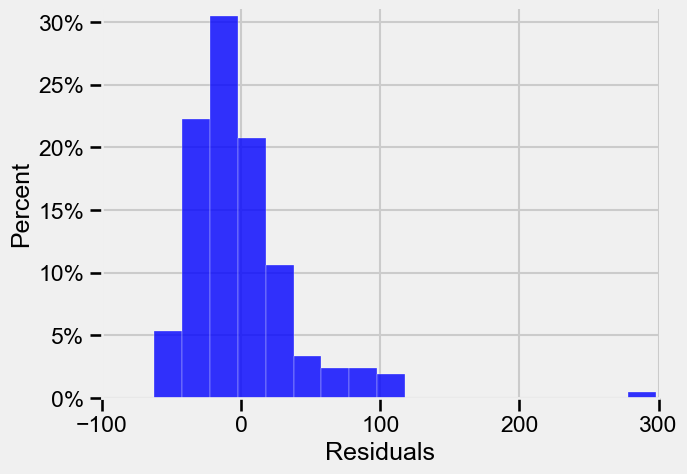

```python
sns.histplot(data=hotels, x="e", binwidth=20, stat="probability", color="blue", alpha=0.8, edgecolor="white", linewidth=0.2)
sns.despine()
#sns.set_style("white")
sns.set(rc={"figure.figsize":(6,4)})
sns.set_palette("deep")

plt.xlabel("Residuals")
plt.ylabel("Percent")
plt.xlim(-100, 300)
plt.ylim(0, 0.31)
plt.xticks(np.arange(-100, 301, 100))
plt.yticks(np.arange(0, 0.31, 0.05), labels=[f"{x:.0%}" for x in np.arange(0, 0.31, 0.05)])
#plt.tight_layout()
plt.show()
```

## Log models

Take log price

```python
hotels["lnprice"] = np.log(hotels["price"])
```

Correct distance2 measure: no closer than 0.05km

```python
hotels["distance2"] = np.where(hotels["distance"] < 0.05, 0.05, hotels["distance"])
```

Take the log of distance2

```python
hotels["lndistance"] = np.log(hotels["distance2"])
```

Describe price and ln price

```python
hotels.filter(["price", "lnprice"]).describe(percentiles=[0.25, 0.5, 0.75, 0.95]).T
```

|  | count | mean | std | min | 25% | 50% | 75% | 95% | max |
| --- | --- | --- | --- | --- | --- | --- | --- | --- | --- |
| price | 207.0 | 109.975845 | 42.221381 | 50.000000 | 82.000000 | 100.00000 | 129.500000 | 183.400000 | 383.000000 |
| lnprice | 207.0 | 4.640219 | 0.336751 | 3.912023 | 4.406719 | 4.60517 | 4.863673 | 5.211657 | 5.948035 |

### Running multiple regressions:

1. Level-level linear regression

```python
reg1 = smf.ols("price ~ distance", data=hotels).fit()
print(reg1.summary())
```

```
                            OLS Regression Results
==============================================================================
Dep. Variable:                  price   R-squared:                       0.157
Model:                            OLS   Adj. R-squared:                  0.153
Method:                 Least Squares   F-statistic:                     38.20
Date:                Fri, 12 May 2023   Prob (F-statistic):           3.39e-09
Time:                        14:59:32   Log-Likelihood:                -1050.3
No. Observations:                 207   AIC:                             2105.
Df Residuals:                     205   BIC:                             2111.
Df Model:                           1
Covariance Type:            nonrobust
==============================================================================
                 coef    std err          t      P>|t|      [0.025      0.975]
------------------------------------------------------------------------------
Intercept    132.0170      4.474     29.511      0.000     123.197     140.837
distance     -14.4064      2.331     -6.181      0.000     -19.002      -9.811
==============================================================================
Omnibus:                      141.994   Durbin-Watson:                   1.479
Prob(Omnibus):                  0.000   Jarque-Bera (JB):             1560.025
Skew:                           2.497   Prob(JB):                         0.00
Kurtosis:                      15.488   Cond. No.                         3.78
==============================================================================

Notes:
[1] Standard Errors assume that the covariance matrix of the errors is correctly specified.
```

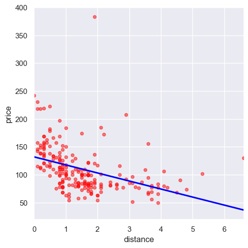

```python
sns.lmplot(x="distance", y="price", data=hotels, scatter_kws={"color": "red", "alpha": 0.5, "s": 20}, line_kws={"color": "blue"}, ci=None)

plt.show()
```

2. Level-log linear regression

```python
reg2 = smf.ols("price ~ lndistance", data=hotels).fit()
print(reg2.summary())
```

```
                            OLS Regression Results
==============================================================================
Dep. Variable:                  price   R-squared:                       0.280
Model:                            OLS   Adj. R-squared:                  0.276
Method:                 Least Squares   F-statistic:                     79.58
Date:                Fri, 12 May 2023   Prob (F-statistic):           2.61e-16
Time:                        14:59:32   Log-Likelihood:                -1034.1
No. Observations:                 207   AIC:                             2072.
Df Residuals:                     205   BIC:                             2079.
Df Model:                           1
Covariance Type:            nonrobust
==============================================================================
                 coef    std err          t      P>|t|      [0.025      0.975]
------------------------------------------------------------------------------
Intercept    112.4171      2.512     44.757      0.000     107.465     117.369
lndistance   -24.7683      2.777     -8.921      0.000     -30.243     -19.294
==============================================================================
Omnibus:                      175.079   Durbin-Watson:                   1.612
Prob(Omnibus):                  0.000   Jarque-Bera (JB):             3501.545
Skew:                           3.084   Prob(JB):                         0.00
Kurtosis:                      22.182   Cond. No.                         1.16
==============================================================================

Notes:
[1] Standard Errors assume that the covariance matrix of the errors is correctly specified.
```

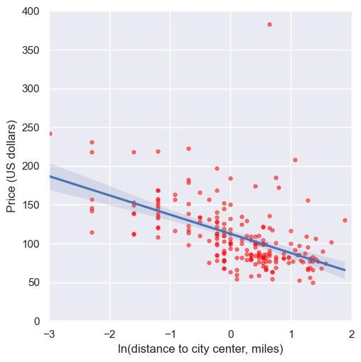

```python
sns.lmplot(x="lndistance", y="price", data=hotels, scatter_kws={"color": "red", "alpha": 0.5, "s": 12})
plt.xlim(-3, 2)
plt.ylim(0, 400)
plt.xlabel("ln(distance to city center, miles)")
plt.ylabel("Price (US dollars)")
plt.show()
```

3. Log-level linear regression

```python
reg3 = smf.ols("lnprice ~ distance", data=hotels).fit()
print(reg3.summary())
```

```
                            OLS Regression Results
==============================================================================
Dep. Variable:                lnprice   R-squared:                       0.205
Model:                            OLS   Adj. R-squared:                  0.201
Method:                 Least Squares   F-statistic:                     52.90
Date:                Fri, 12 May 2023   Prob (F-statistic):           7.30e-12
Time:                        14:59:33   Log-Likelihood:                -44.160
No. Observations:                 207   AIC:                             92.32
Df Residuals:                     205   BIC:                             98.99
Df Model:                           1
Covariance Type:            nonrobust
==============================================================================
                 coef    std err          t      P>|t|      [0.025      0.975]
------------------------------------------------------------------------------
Intercept      4.8411      0.035    139.720      0.000       4.773       4.909
distance      -0.1313      0.018     -7.273      0.000      -0.167      -0.096
==============================================================================
Omnibus:                       28.470   Durbin-Watson:                   1.564
Prob(Omnibus):                  0.000   Jarque-Bera (JB):               47.450
Skew:                           0.746   Prob(JB):                     4.97e-11
Kurtosis:                       4.809   Cond. No.                         3.78
==============================================================================

Notes:
[1] Standard Errors assume that the covariance matrix of the errors is correctly specified.
```

4. Log-log linear regression

```python
reg4 = smf.ols("lnprice ~ lndistance", data=hotels).fit()
print(reg4.summary())
```

```
                            OLS Regression Results
==============================================================================
Dep. Variable:                lnprice   R-squared:                       0.334
Model:                            OLS   Adj. R-squared:                  0.330
Method:                 Least Squares   F-statistic:                     102.6
Date:                Fri, 12 May 2023   Prob (F-statistic):           8.18e-20
Time:                        14:59:33   Log-Likelihood:                -25.911
No. Observations:                 207   AIC:                             55.82
Df Residuals:                     205   BIC:                             62.49
Df Model:                           1
Covariance Type:            nonrobust
==============================================================================
                 coef    std err          t      P>|t|      [0.025      0.975]
------------------------------------------------------------------------------
Intercept      4.6615      0.019    241.926      0.000       4.623       4.699
lndistance    -0.2158      0.021    -10.130      0.000      -0.258      -0.174
==============================================================================
Omnibus:                       47.573   Durbin-Watson:                   1.742
Prob(Omnibus):                  0.000   Jarque-Bera (JB):              128.794
Skew:                           0.976   Prob(JB):                     1.08e-28
Kurtosis:                       6.335   Cond. No.                         1.16
==============================================================================

Notes:
[1] Standard Errors assume that the covariance matrix of the errors is correctly specified.
```

#### Checking and comparing all models:

```python
table = Stargazer([reg1, reg2, reg3, reg4])
table.rename_covariates({"Intercept": "Constant"})
table.custom_columns(["Level-Level", "Level-Log", "Log-Level", "Log-Log"], [1, 1, 1, 1])
table
```

|  | Level-Level | Level-Log | Log-Level | Log-Log |
| --- | --- | --- | --- | --- |
|  | (1) | (2) | (3) | (4) |
| Constant | 132.017*** | 112.417*** | 4.841*** | 4.661*** |
|  | (4.474) | (2.512) | (0.035) | (0.019) |
| distance | -14.406*** |  | -0.131*** |  |
|  | (2.331) |  | (0.018) |  |
| lndistance |  | -24.768*** |  | -0.216*** |
|  |  | (2.777) |  | (0.021) |
| Observations | 207 | 207 | 207 | 207 |
| R<sup>2</sup> | 0.157 | 0.280 | 0.205 | 0.334 |
| Adjusted R<sup>2</sup> | 0.153 | 0.276 | 0.201 | 0.330 |
| Residual Std. Error | 38.858 (df=205) | 35.923 (df=205) | 0.301 (df=205) | 0.276 (df=205) |
| F Statistic | 38.199*** (df=1; 205) | 79.576*** (df=1; 205) | 52.895*** (df=1; 205) | 102.622*** (df=1; 205) |
| Note: | *p<0.1; **p<0.05; ***p<0.01 |  |  |  |

## Polynomials

```python
hotels["dist_sq"] = hotels["distance"]**2
hotels["dist_cb"] = hotels["distance"]**3
```

5. Single squared

```python
reg5 = smf.ols("price ~ distance + dist_sq", data=hotels).fit()
print(reg5.summary())
```

```
                            OLS Regression Results
==============================================================================
Dep. Variable:                  price   R-squared:                       0.258
Model:                            OLS   Adj. R-squared:                  0.251
Method:                 Least Squares   F-statistic:                     35.44
Date:                Fri, 12 May 2023   Prob (F-statistic):           6.18e-14
Time:                        14:59:33   Log-Likelihood:                -1037.1
No. Observations:                 207   AIC:                             2080.
Df Residuals:                     204   BIC:                             2090.
Df Model:                           2
Covariance Type:            nonrobust
==============================================================================
                 coef    std err          t      P>|t|      [0.025      0.975]
------------------------------------------------------------------------------
Intercept    154.8580      6.045     25.617      0.000     142.939     166.777
distance     -46.0140      6.394     -7.197      0.000     -58.620     -33.408
dist_sq        6.9277      1.316      5.263      0.000       4.332       9.523
==============================================================================
Omnibus:                      177.585   Durbin-Watson:                   1.551
Prob(Omnibus):                  0.000   Jarque-Bera (JB):             3582.408
Skew:                           3.149   Prob(JB):                         0.00
Kurtosis:                      22.382   Cond. No.                         23.5
==============================================================================

Notes:
[1] Standard Errors assume that the covariance matrix of the errors is correctly specified.
```

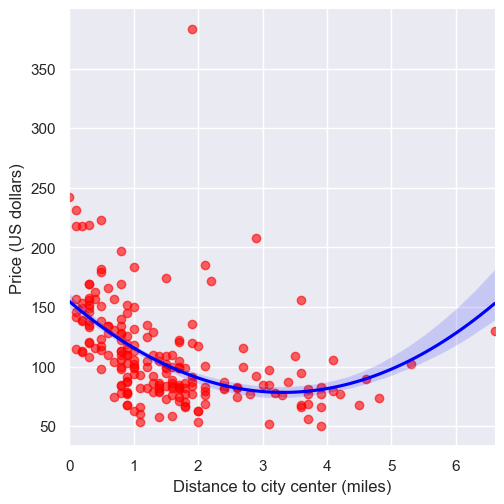

```python
sns.lmplot(x="distance", y="price", data=hotels, order=2, ci=68, scatter_kws={"color": "red", "alpha": 0.6}, line_kws={"color": "blue"})

plt.xlabel("Distance to city center (miles)")
plt.ylabel("Price (US dollars)")
plt.show()
```

6. Squared and cubic

```python
reg6 = smf.ols("price ~ distance + dist_sq + dist_cb", data=hotels).fit()
print(reg6.summary())
```

```
                            OLS Regression Results
==============================================================================
Dep. Variable:                  price   R-squared:                       0.276
Model:                            OLS   Adj. R-squared:                  0.265
Method:                 Least Squares   F-statistic:                     25.74
Date:                Fri, 12 May 2023   Prob (F-statistic):           3.75e-14
Time:                        14:59:33   Log-Likelihood:                -1034.6
No. Observations:                 207   AIC:                             2077.
Df Residuals:                     203   BIC:                             2091.
Df Model:                           3
Covariance Type:            nonrobust
==============================================================================
                 coef    std err          t      P>|t|      [0.025      0.975]
------------------------------------------------------------------------------
Intercept    165.6994      7.715     21.477      0.000     150.487     180.912
distance     -70.0162     12.496     -5.603      0.000     -94.656     -45.377
dist_sq       18.4468      5.332      3.460      0.001       7.933      28.960
dist_cb       -1.4070      0.632     -2.228      0.027      -2.652      -0.162
==============================================================================
Omnibus:                      184.317   Durbin-Watson:                   1.592
Prob(Omnibus):                  0.000   Jarque-Bera (JB):             4186.402
Skew:                           3.282   Prob(JB):                         0.00
Kurtosis:                      24.031   Cond. No.                         191.
==============================================================================

Notes:
[1] Standard Errors assume that the covariance matrix of the errors is correctly specified.
```

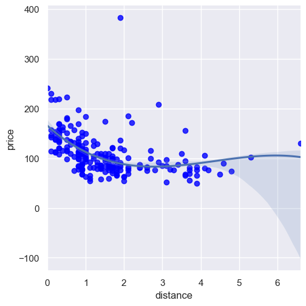

```python
sns.lmplot(x="distance", y="price", data=hotels, ci=68, order=3, scatter_kws={"color": "blue"})
plt.show()
```

Compare these non-linear models:

```python
table = Stargazer([reg1, reg5, reg6])
table.rename_covariates({"Intercept": "Constant"})
table.custom_columns(["Linear", "Squared", "Cubic"], [1, 1, 1])
table
```

|  | *Dependent variable:price* |  |  |
| --- | --- | --- | --- |
|  | Linear | Squared | Cubic |
|  | (1) | (2) | (3) |
| Constant | 132.017*** | 154.858*** | 165.699*** |
|  | (4.474) | (6.045) | (7.715) |
| dist_cb |  |  | -1.407** |
|  |  |  | (0.632) |
| dist_sq |  | 6.928*** | 18.447*** |
|  |  | (1.316) | (5.332) |
| distance | -14.406*** | -46.014*** | -70.016*** |
|  | (2.331) | (6.394) | (12.496) |
| Observations | 207 | 207 | 207 |
| R<sup>2</sup> | 0.157 | 0.258 | 0.276 |
| Adjusted R<sup>2</sup> | 0.153 | 0.251 | 0.265 |
| Residual Std. Error | 38.858 (df=205) | 36.551 (df=204) | 36.201 (df=203) |
| F Statistic | 38.199*** (df=1; 205) | 35.435*** (df=2; 204) | 25.737*** (df=3; 203) |
| Note: | *p<0.1; **p<0.05; ***p<0.01 |  |  |

```python
hotels['price'].corr(hotels['distance'])
```

```
-0.3963195380148178
```

```python
hotels['distance'].corr(hotels['price'])
```

```
-0.39631953801481784
```